# A18.17

$$\left[ \frac{\pi^4 a b}{4} C_{mn} \left( \frac{m^2}{a^2} + \frac{n^2}{b^2} \right)^2 - P \sin \frac{m \pi \xi}{a} \cdot \sin \frac{n \pi \eta}{b} \right] \delta C_{mn} = 0$$

$\delta C_{mn}$ は任意であるため、その係数はゼロでなければならない。したがって：

$$C_{mn} = \frac{4 P \sin \frac{m \pi \xi}{a} \cdot \sin \frac{n \pi \eta}{b}}{\pi^4 a b D \left( \frac{m^2}{a^2} + \frac{n^2}{b^2} \right)^2}$$

$$w = \frac{4 P}{\pi^4 a b D} \sum_{m=1}^{\infty} \sum_{n=1}^{\infty} \frac{\sin \frac{m \pi \xi}{a} \cdot \sin \frac{n \pi \eta}{b}}{\left( \frac{m^2}{a^2} + \frac{n^2}{b^2} \right)^2} \cdot \sin \frac{m \pi x}{a} \cdot \sin \frac{n \pi y}{b} \quad \text{--- } (24d)$$

この級数は急速に収束する。正方形板（ $a/b = 1$ ）の場合：

$$w_{\text{max}} = \frac{4 P a^2}{\pi^4 D} \sum_{m=1}^{\infty} \sum_{n=1}^{\infty} \frac{1}{(m^2 + n^2)^2} \quad \text{--- } (24e)$$

最初の4項のみを考慮すると、以下が得られる：

$$w_{\text{max}} \approx 0.01121 \frac{P a^2}{D}$$

これは正確な値より $3 \text{--} 1/2 \%$ 小さい。

2. 対向する2辺が単純支持され、第3の辺が自由、第4の辺が固定または単純支持された長方形板。

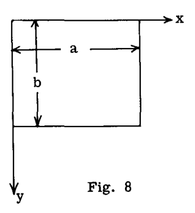

Fig. 8

辺 $x = 0$ および $x = a$ が単純支持され、辺 $y = b$ が自由、辺 $y = 0$ が固定されていると仮定する（Fig. 8）。このような場合、境界条件は以下の通りである：

$$w = 0, \quad \frac{\partial^2 w}{\partial x^2} = 0, \quad \text{for } x = 0, x = a \quad \text{(a)}$$

$$w = 0, \quad \frac{\partial w}{\partial y} = 0, \quad \text{for } y = 0 \quad \text{(b)}$$

$$\left( \frac{\partial^2 w}{\partial x^2} + \frac{\partial^2 w}{\partial y^2} \right) = 0, \quad \left[ \frac{\partial^3 w}{\partial y^3} + 2(1-
u) \frac{\partial^3 w}{\partial x^2 \partial y} \right] = 0 \quad \text{for } y = b \quad \text{(c)} \quad \text{--- } (25)$$

均一荷重 $q$ の場合を考えてみよう。たわみを以下の形式で記述する：

$$w = w_1 + w_2 \quad \text{--- } (26a)$$

ここで $w_1$ は、長さ $a$ の単純支持された帯板のたわみであり、Fig. 8 の座標系に対して以下のように書くことができる（前節のレヴィの方法を参照）：

$$w_1 = \frac{4 q a^4}{\pi^5 D} \sum_{m=1,3,5}^{\infty} \frac{1}{m^5} \sin \frac{m \pi x}{a}$$

そして $w_2$ は以下の級数で表される：

$$w_2 = \sum_{m=1,3,5}^{\infty} Y_m(y) \sin \frac{m \pi x}{a} \quad \text{--- } (26c)$$

ここで $w_2$ は以下の解である：

$$\frac{\partial^4 w_2}{\partial x^4} + \frac{\partial^4 w_2}{\partial y^4} + 2 \frac{\partial^4 w_2}{\partial x^2 \partial y^2} = 0$$

これは前節と同様に以下のように求められる：

$$Y_m = \frac{q a^4}{D} \left( A_m \cosh \frac{m \pi y}{a} + B_m \frac{m \pi y}{a} \sinh \frac{m \pi y}{a} + C_m \sinh \frac{m \pi y}{a} + D_m \frac{m \pi y}{a} \cosh \frac{m \pi y}{a} \right) \quad \text{--- } (26d)$$

最初の2つの境界条件が $w = w_1 + w_2$ によって恒等的に満たされることは明らかである。係数 $A_m, B_m, C_m, D_m$ は、残りの4つの境界条件を満たすように決定されなければならない。条件 (25b) を使用すると、以下が得られる：

$$A_m = -\frac{4}{\pi^5 m^5}, \quad C_m = -D_m$$

条件 (25c) により、以下が得られる：

$$B_m = -\frac{4}{\pi^5 m^5} \frac{(3+
u)(1-
u) \cosh^2 \beta_m + 2
u \cosh \beta_m - (1-
u)^2 \beta_m \sinh \beta_m - (1-
u)^2}{(3+
u)(1-
u) \cosh^2 \beta_m + (1-
u)^2 \beta_m^2 + (1+
u)^2}$$

$$C_m = -\frac{4}{\pi^5 m^5} \frac{(3+
u)(1-
u) \sinh \beta_m \cosh \beta_m + (1+
u)(1-
u) \sinh \beta_m - (1-
u)^2 \beta_m \cosh \beta_m}{(3+
u)(1-
u) \cosh^2 \beta_m + (1-
u)^2 \beta_m^2 + (1+
u)^2} \quad \text{--- } (26e)$$

$A_m, B_m, C_m, D_m$ を式 (26d) に代入することで、たわみが求められる。最大たわみは自由辺の中央で発生する。

## A18.14 薄板の曲げと引張または圧縮の組合せ

前ページで平衡の微分方程式を導出する際、板は板に垂直な横荷重によって曲げられ、そのたわみは中間面の引き伸ばしを無視できるほど小さいと仮定されていた。今、面内の端部荷重のみが作用する場合を考えると、

# A18.18 THEORY OF THE INSTABILITY OF COLUMNS AND THIN SHEETS

中間面に関して（Fig. 9）、平面応力問題が発生する。応力が厚さ方向に均一に分布していると仮定し、 $x$ 方向および $y$ 方向の線形要素の単位長さあたりのこれらの応力の合力を $N_x, N_y, N_{xy}, N_{yx}$ と表すと（Fig. 9）、以下は明らかである：

$$\left. \begin{aligned}
N_x &= h \sigma_x, \quad N_y = h \sigma_y \\
N_{xy} &= N_{yx} = h \tau_{xy} = h \tau_{yx}
\end{aligned} \right\} \quad \text{--- } (27)$$

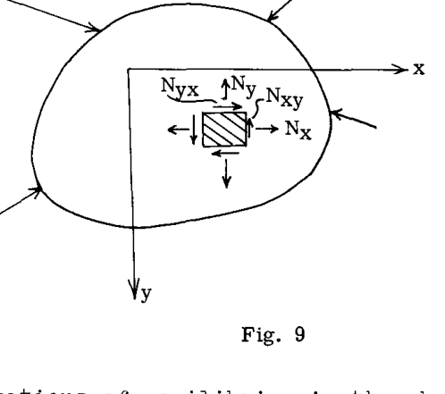

Fig. 9

体力が存在しない場合の平衡方程式は、式 (27) を平衡方程式に代入することにより、これらの一般化された応力 $N_x, N_y, N_{xy}$ を用いて以下のように書くことができる：

$$\frac{\partial N_x}{\partial x} + \frac{\partial N_{xy}}{\partial y} = 0, \quad \frac{\partial N_y}{\partial y} + \frac{\partial N_{xy}}{\partial x} = 0 \quad \text{--- } (28)$$

他方、板に横荷重が作用する場合、応力は純粋な曲げモーメントおよびねじりモーメントのみを発生させる。後者の平衡方程式は以前に示されている（式 6, 7, 8 を参照）。横荷重と面内端部荷重の両方が同時に作用する場合、小さな垂直たわみに対しては、応力状態は $N_x, N_y, N_{xy}$ による応力と $M_x, M_y, M_{xy}$ による応力の重ね合わせとなる。しかし、板の大きな垂直たわみに対しては、面内応力とたわみの相互作用が存在する。これらの応力は、梁の場合と同様に、たわんだ中間面からの端部荷重の非ゼロのレバーアームにより、追加の曲げモーメントを発生させる。端部荷重が圧縮の場合、この追加のモーメントは、過度な垂直たわみによる板の不安定性および破壊を引き起こす可能性がある。

本章では、板の不安定性の問題について検討する。

端部荷重が圧縮であり、追加の曲げモーメントを発生させる場合、式 (8) は修正されなければならない。

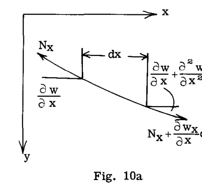

Fig. 10a

中間面の微小要素 $dx, dy$ を考える（Fig. 10a）。 $x, y$ 方向の力の平衡条件は式 (28) によって与えられる。ここで、応力 $N_x, N_y, N_{xy}$ の $z$ 方向への投影を考える：

1. $N_x$ の投影：Fig. 10a より、合力の投影は以下のようになる：

$$- N_x \partial y \frac{\partial w}{\partial x} + \left( N_x + \frac{\partial N_x}{\partial x} dx \right) \left( \frac{\partial w}{\partial x} + \frac{\partial^2 w}{\partial x^2} dx \right)$$

高次の項を無視すると：

$$\left( N_x \frac{\partial^2 w}{\partial x^2} + \frac{\partial N_x}{\partial x} \frac{\partial w}{\partial x} \right) dx dy \quad \text{--- } (a)$$

2. $N_y$ の投影：同様の議論により、この投影は以下に等しいことがわかる：

$$\left( N_y \frac{\partial^2 w}{\partial y^2} + \frac{\partial N_y}{\partial y} \frac{\partial w}{\partial y} \right) dx dy \quad \text{--- } (b)$$

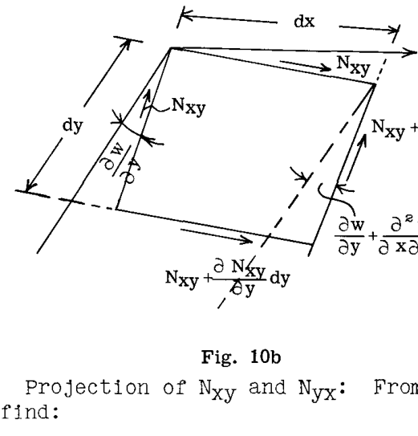

Fig. 10b

3. $N_{xy}$ および $N_{yx}$ の投影：Fig. 10b より、以下が得られる：

$$- N_{xy} \frac{\partial w}{\partial y} + \left( N_{xy} + \frac{\partial N_{xy}}{\partial x} dx \right) \left( \frac{\partial w}{\partial y} + \frac{\partial^2 w}{\partial x \partial y} dx \right)$$

高次の項を無視すると：

$$\left( N_{xy} \frac{\partial^2 w}{\partial x \partial y} + \frac{\partial N_{xy}}{\partial x} \frac{\partial w}{\partial y} \right) dx dy \quad \text{--- } (c)$$

同様に、 $N_{yx} = N_{xy}$ の投影を求めると：

# A18.19

$$\left( N_{xy} \frac{\partial^2 w}{\partial x \partial y} + \frac{\partial N_{xy}}{\partial y} \frac{\partial w}{\partial x} \right) dx dy \quad \text{--- } (d)$$

したがって、式 (6a) において、(a), (b), (c), (d) で与えられる項を加算する必要がある（当然、 $dx dy$ で除算する）：

$$\frac{\partial Q_x}{\partial x} + \frac{\partial Q_y}{\partial y} + q + N_x \frac{\partial^2 w}{\partial x^2} + N_y \frac{\partial^2 w}{\partial y^2} + 2 N_{xy} \frac{\partial^2 w}{\partial x \partial y} + \left( \frac{\partial N_x}{\partial x} + \frac{\partial N_{xy}}{\partial y} \right) \frac{\partial w}{\partial x} + \left( \frac{\partial N_y}{\partial y} + \frac{\partial N_{xy}}{\partial x} \right) \frac{\partial w}{\partial y} = 0 \quad \text{--- } (e)$$

しかし、平衡方程式 (28) により、(e) の括弧内の2つの項はゼロである。したがって：

$$\frac{\partial Q_x}{\partial x} + \frac{\partial Q_y}{\partial y} + q + N_x \frac{\partial^2 w}{\partial x^2} + N_y \frac{\partial^2 w}{\partial y^2} + 2 N_{xy} \frac{\partial^2 w}{\partial x \partial y} = 0 \quad \text{--- } (29)$$

面内応力 $N_x, N_y, N_{xy}$ の分布は、平面応力問題を解くことによって式 (28) から見つけることができる。以下では、上記の理論を長方形板に適用する。

## A18.15 端部圧縮および曲げによる板のひずみエネルギー

純粋な曲げに対するエネルギー式（式 11）は、端部面内荷重の寄与を含めるように補完されなければならない。まず端部荷重が作用すると仮定する。明らかに、応力 $N_x, N_y, N_{xy}$ によるひずみは以下の通りである：

$$\epsilon_x^0 = \frac{1}{h E} (N_x -
u N_y), \quad \epsilon_y^0 = \frac{1}{h E} (N_y -
u N_x), \quad \gamma_{xy}^0 = \frac{N_{xy}}{h G} \quad \text{--- } (31)$$

ひずみエネルギーは：

$$V_{1N} = \frac{1}{2} \iint (N_x \epsilon_x^0 + N_y \epsilon_y^0 + N_{xy} \gamma_{xy}^0) dxdy = \frac{1}{2 h E} \iint (N_x^2 + N_y^2 - 2
u N_x N_y + 2(1+
u)N_{xy}^2) dxdy \quad \text{--- } (a)$$

横荷重による曲げの際、または座屈の際、端部荷重、したがって $N_x, N_y, N_{xy}$ は一定に保たれると仮定する。したがって、その変化はゼロであり、以下では考慮しない。ここで、曲げを発生させる横荷重を作用させる。（座屈の場合である他の横方向の乱れによる曲げを考えることもできる）。 $u, v$ が面内荷重（厚さ方向に一定と仮定される）による中間面の変位であり、 $w$ が板の曲げたわみである場合、ひずみは以下のようになることが示される：

$$\begin{aligned}
\epsilon_x &= \frac{\partial u}{\partial x} + \frac{1}{2} \left( \frac{\partial w}{\partial x} \right)^2 \\
\epsilon_y &= \frac{\partial v}{\partial y} + \frac{1}{2} \left( \frac{\partial w}{\partial y} \right)^2 \\
\gamma_{xy} &= \frac{\partial u}{\partial y} + \frac{\partial v}{\partial x} + \frac{\partial w}{\partial x} \frac{\partial w}{\partial y}
\end{aligned} \quad \text{--- } (b)$$

ここで、一定の面内応力の下で曲げを適用してみよう。中間面の引き伸ばしによるエネルギーは：

$$\iint (N_x \epsilon_x + N_y \epsilon_y + N_{xy} \gamma_{xy}) dxdy \quad \text{--- } (c)$$

2. を (c) に導入し、式 (11) による曲げひずみエネルギーを加算すると、曲げによるひずみエネルギーの全変化が得られる：

$$\begin{aligned}
V_1 &= \iint \left[ N_x \frac{\partial u}{\partial x} + N_y \frac{\partial v}{\partial y} + N_{xy} \left( \frac{\partial u}{\partial y} + \frac{\partial v}{\partial x} \right) \right] dxdy \\
&\quad + \frac{1}{2} \iint \left[ N_x \left( \frac{\partial w}{\partial x} \right)^2 + N_y \left( \frac{\partial w}{\partial y} \right)^2 + 2 N_{xy} \frac{\partial w}{\partial x} \frac{\partial w}{\partial y} \right] dxdy \\
&\quad + \frac{1}{2} D \iint \left\{ \left( \frac{\partial^2 w}{\partial x^2} + \frac{\partial^2 w}{\partial y^2} \right)^2 - 2(1-
u) \left[ \frac{\partial^2 w}{\partial x^2} \frac{\partial^2 w}{\partial y^2} - \left( \frac{\partial^2 w}{\partial x \partial y} \right)^2 \right] \right\} dxdy \quad \text{--- } (d)
\end{aligned}$$

ここで $u, v$ は、曲げ開始後の追加の面内変位である。部分積分により、最初の積分は曲げ中に端部荷重によって行われる仕事であることが示される。例えば、長方形板の場合、この積分は次のようになる：

$$\begin{aligned}
&\int_0^a \int_0^b \left[ N_x \frac{\partial u}{\partial x} + N_y \frac{\partial v}{\partial y} + N_{xy} \left( \frac{\partial u}{\partial y} + \frac{\partial v}{\partial x} \right) \right] dxdy \\
&= \int_0^b \left( \left. N_x u \right|_0^a + \left. N_{xy} v \right|_0^a \right) dy + \int_0^a \left( \left. N_y v \right|_0^b + \left. N_{xy} u \right|_0^b \right) dx \\
&\quad - \int_0^a \int_0^b \left\{ u \left( \frac{\partial N_x}{\partial x} + \frac{\partial N_{xy}}{\partial y} \right) + v \left( \frac{\partial N_y}{\partial y} + \frac{\partial N_{xy}}{\partial x} \right) \right\} dxdy \quad \text{--- } (e)
\end{aligned}$$

# A18.20 THEORY OF THE INSTABILITY OF COLUMNS AND THIN SHEETS

明らかに、最初の2つの積分は端部荷重によって行われる仕事を表し、2番目の積分は平衡方程式 (28) のためゼロである。したがって、端部荷重の仕事は次のようになる：

$$W_N = \iint \left[ N_x \frac{\partial u}{\partial x} + N_y \frac{\partial v}{\partial y} + N_{xy} \left( \frac{\partial u}{\partial y} + \frac{\partial v}{\partial x} \right) \right] dxdy \quad \text{--- } (f)$$

ここで、小たわみに対しては板の中間面の引き伸ばしは無視できると仮定する。（これは板のいわゆる不伸長理論である）。この場合、式 (b) のひずみをゼロにし、(f) に代入すると、以下が得られる：

$$W_N = -\frac{1}{2} \iint \left[ N_x \left( \frac{\partial w}{\partial x} \right)^2 + N_y \left( \frac{\partial w}{\partial y} \right)^2 + 2 N_{xy} \frac{\partial w}{\partial x} \frac{\partial w}{\partial y} \right] dxdy \quad \text{--- } (32a)$$

ひずみエネルギーの式 (a) において、最初の2つの項は互いに相殺され、ひずみエネルギーは曲げのみによるものとなる：

$$\begin{aligned}
V_1 &= \frac{1}{2} D \iint \left\{ \left( \frac{\partial^2 w}{\partial x^2} + \frac{\partial^2 w}{\partial y^2} \right)^2 \right. \\
&\quad \left. - 2(1-
u) \left[ \frac{\partial^2 w}{\partial x^2} \frac{\partial^2 w}{\partial y^2} - \left( \frac{\partial^2 w}{\partial x \partial y} \right)^2 \right] \right\} dxdy \quad \text{--- } (32b)
\end{aligned}$$

横荷重がない場合、外力の仕事は単に端部荷重によるものである：

$$W = W_N \quad \text{--- } (32c)$$

式 (32b) および (c) は、仮想仕事の原理によって座屈問題を解決するために使用される。

## A18.16 様々な端部荷重および支持条件を持つ長方形板の座屈

### 一般的な議論

平坦な平衡状態が不安定になり、板が座屈し始める端部荷重の臨界値を計算する際、圧縮棒と同様の方法および対応する推論が採用される。

臨界値は、板にわずかな初期曲率または小さな横荷重があると仮定することによって得ることができる。横たわみ $w$ が無限大になる端部荷重のこれらの値が臨界値である（柱における同様の処理についてはパート1を参照）。

$$\frac{\partial^4 w}{\partial x^4} + 2 \frac{\partial^4 w}{\partial x^2 \partial y^2} + \frac{\partial^4 w}{\partial y^4} = \frac{1}{D} \left( N_x \frac{\partial^2 w}{\partial x^2} + N_y \frac{\partial^2 w}{\partial y^2} + 2 N_{xy} \frac{\partial^2 w}{\partial x \partial y} \right) \quad \text{--- } (33)$$

式 (33) を解くことにより、端部荷重のある確定した値に対して、想定された座屈モードが可能である（ $w eq 0$ ）ことがわかり、その最小値が臨界荷重を決定する。エネルギー法は座屈問題の調査にも使用できる。この方法では、板は最初、端部荷重による平面応力状態にあり、応力分布は既知であると仮定する。次に、座屈した状態を平衡の可能な構成として検討する。仕事の変化は式 (32a) によって与えられる。ここでは $\delta$ 記号を使用しないが、 $w$ を仮想変位として解釈する。したがって、仕事の増分 $\delta W$ は (32a) によって与えられ、ひずみエネルギーの増分 $\delta V_1$ は式 (32b) によって与えられる。あらゆる可能な座屈形状に対して $\delta W < \delta V_1$ である場合、平坦な平衡は安定している。ある座屈形状に対して $\delta W > \delta V_1$ である場合、平坦な構成は不安定であり、板は臨界荷重を超える荷重の下で座屈する。 $\delta W = \delta V_1$ である場合、平衡は中立であり、この方程式から臨界荷重が求められる。したがって、臨界荷重は以下の方程式から求められる：

$$\begin{aligned}
&-\frac{1}{2} \iint \left[ N_x \left( \frac{\partial w}{\partial x} \right)^2 + N_y \left( \frac{\partial w}{\partial y} \right)^2 + 2 N_{xy} \frac{\partial w}{\partial x} \frac{\partial w}{\partial y} \right] dxdy = \\
&\frac{D}{2} \iint \left\{ \left( \frac{\partial^2 w}{\partial x^2} + \frac{\partial^2 w}{\partial y^2} \right)^2 - 2(1-
u) \left[ \frac{\partial^2 w}{\partial x^2} \frac{\partial^2 w}{\partial y^2} - \left( \frac{\partial^2 w}{\partial x \partial y} \right)^2 \right] \right\} dxdy \quad \text{--- } (34)
\end{aligned}$$

ここで $w$ は、境界条件を満たす特定の仮定されたたわみ（仮想たわみ）である。

## A18.17 一方向に均一に圧縮された単純支持長方形板の座屈

辺が $a$ および $b$ の板（Fig. 11）が、その周辺を単純支持され、辺 $x = 0$ および $x = a$ に沿って均一に分布した荷重 $N_x$ によって圧縮されているとする。対応する平面応力問題の

# A18.21

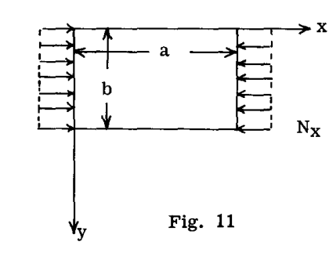

Fig. 11

明らかな解から、応力状態はいたるところで $N_x$ （周辺の荷重）に等しい単純圧縮であることがわかる。

曲げが発生したときの単純支持板のたわみ面は、以前に求められている（式 14a を参照）。その一般的な表現は、二重級数の形式で書くことができる：

$$w = \sum_{m=1}^{\infty} \sum_{n=1}^{\infty} C_{mn} \sin \frac{m \pi x}{a} \cdot \sin \frac{n \pi y}{b} \quad \text{--- } (35a)$$

式 (35a) を (34) の右辺に代入して得られるひずみエネルギーの増分は以下の通りである：

$$\delta V_1 = \frac{\pi^4 a b}{8} D \sum_{m=1}^{\infty} \sum_{n=1}^{\infty} C_{mn}^2 \left( \frac{m^2}{a^2} + \frac{n^2}{b^2} \right)^2 \quad \text{--- } (35b)$$

外力によって行われる仕事の増分は、(35a) を式 (34) の左辺に代入し、 $N_x = \text{const}, N_y = N_{xy} = 0$ とすることによって求められる。したがって：

$$\begin{aligned}
\delta W &= \frac{1}{2} N_x \int_0^a \int_0^b \left( \frac{\partial w}{\partial x} \right)^2 dxdy = \\
&\frac{\pi^2 b}{8 a} N_x \sum_{m=1}^{\infty} \sum_{n=1}^{\infty} m^2 C_{mn}^2 \quad \text{--- } (35c)
\end{aligned}$$

等価性 $\delta W = \delta V_1$ から $N_x$ について解くと、以下が得られる：

$$N_x = \frac{\pi^2 a^2 D \sum_{m=1}^{\infty} \sum_{n=1}^{\infty} C_{mn}^2 \left( \frac{m^2}{a^2} + \frac{n^2}{b^2} \right)^2}{\sum_{m=1}^{\infty} \sum_{n=1}^{\infty} m^2 C_{mn}^2} \quad \text{--- } (35d)$$

ここで $C_{mn}$ は任意である。しかし、我々は $N_x$ を最小にする $C_{mn}$ の値に関心がある。そのために、以下の数学的推論を使用する：

一連の分数を想定する：

$$\frac{a}{b}, \frac{c}{d}, \frac{e}{f}, \dots \quad \text{--- } (a)$$

分子と分母を加算すると、次の分数が得られる：

$$\frac{a + c + e + \dots}{b + d + f + \dots} \quad \text{--- } (b)$$

この分数は、分数 (a) の最大値と最小値の間のいくつかの中間値を持つ。式 (35d) の分数に類似した分数 (b) を最小にするには、分子に1つの項のみを、分母に対応する項をとる必要がある。したがって、式 (35d) の分数を最小にするには、1つを除いてすべてのパラメータ $C_{11}, C_{12}, C_{21}, \dots$ をゼロにする必要がある。これは、座屈形状が両方向において単純な正弦波形状、すなわち次式のようになると仮定することと同等である。

$$w_{mn} = C_{mn} \sin \frac{m \pi x}{a} \cdot \sin \frac{n \pi y}{b}$$

$C_{mn}$ を除くすべての項を落とすことによって得られる $N_x$ の最小の表現は、次のようになる：

$$Nx = \frac{\pi^2 a^2 D}{m^2} \left( \frac{m^2}{a^2} + \frac{n^2}{b^2} \right)^2 \quad \text{--- } (35e)$$

$N_x$ の最小値は $n = 1$ とすることによって得られることは明らかである。これは、板が常に、圧縮方向にはいくつかの半波が存在し得るが、垂直方向には1つの半波のみが存在するように座屈することを意味する。したがって、 $n = 1$ に対して、式 (35e) は次のようになる：

$$(N_x)_{\text{cr}} = \frac{\pi^2 D}{a^2} \left( m + \frac{1}{m} \frac{a^2}{b^2} \right)^2 \quad \text{--- } (36a)$$

この臨界値を可能な限り最小にする $m$ の値（換言すれば半波の数）は、比 $a/b$ に依存し、以下のように求めることができる：

式 (36a) を次の形式で表現してみよう：

$$(N_x)_{\text{cr}} = k \frac{\pi^2 D}{b^2} \quad \text{--- } (36b)$$

ここで $k$ は $(a/b)$ に依存する数値係数である。 (36a) と (36b) から、以下が得られる：

$$k = \left( \frac{b}{a} m + \frac{a}{b} \frac{1}{m} \right)^2 \quad \text{--- } (36c)$$

様々な整数 $m = 1, 2, 3, \dots$ に対して $k$ を $a/b$ に対してプロットすると、Fig. 12 の曲線が得られる。これらの曲線から、臨界荷重係数 $k$ と対応する半波の数を容易に決定することができる。実軸として対応する点 $(a/b)$ をとり、最小の $k$ を与える曲線を選択するだけでよい。Fig. 12 において、 $k$ の臨界値を与える様々な曲線の一部は実線で示されている。 $m$ から $(m + 1)$ 個の半波への移行は、対応する2つの曲線の交点で発生する。式 (36c) から以下が得られる：

# A18.22 THEORY OF THE INSTABILITY OF COLUMNS AND THIN SHEETS

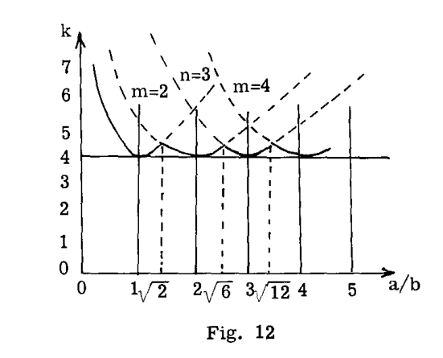

Fig. 12

$$\frac{m b}{a} + \frac{a}{m b} = \frac{(m+1)b}{a} + \frac{a}{(m+1)b} \quad \text{or:}$$

$$\frac{a}{b} = \sqrt{m(m+1)} \quad \text{--- } (36d)$$

したがって、1つから2つの半波への移行は次の場合に発生する：

$$\frac{a}{b} = \sqrt{1(1+1)} = \sqrt{2}$$

2つから3つの半波へは次の場合である：

$$\frac{a}{b} = \sqrt{2(2+1)} = \sqrt{6}$$

以下同様である。

半波の数は比 $a/b$ につれて増加し、非常に長い板に対しては $m$ は非常に大きくなる。

$$\frac{a}{b} \approx m$$

これは、非常に長い板が、その長さが板の幅に近づく半波で座屈することを意味する。座屈した板は正方形に細分化される。

圧縮応力の臨界値は次の通りである：

$$\sigma_{\text{cr}} = \frac{(N_x)_{\text{cr}}}{h} = \frac{k \pi^2 E}{12(1-
u^2)} \frac{t^2}{b^2} \quad \text{--- } (36e)$$

（ $t = \text{厚さ}$ ）

## A18.18 2つの垂直な方向に圧縮された単純支持長方形板の座屈

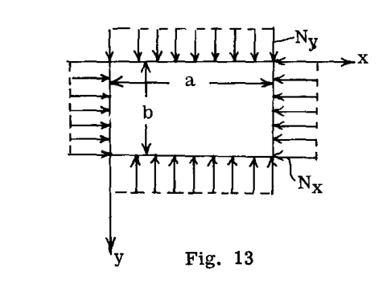

Fig. 13

$$N_x \frac{m^2 \pi^2}{a^2} + N_y \frac{n^2 \pi^2}{b^2} = D \left( \frac{m^2 \pi^2}{a^2} + \frac{n^2 \pi^2}{b^2} \right)^2 \quad \text{--- } (37a)$$

そして、パラメータを導入することにより：

$$\sigma_{\text{e}} = \frac{\pi^2 D}{a^2 h} \quad \text{--- } (37b)$$

以下が得られる：

$$\sigma_x m^2 + \sigma_y n^2 \frac{a^2}{b^2} = \sigma_{\text{e}} \left( m^2 + n^2 \frac{a^2}{b^2} \right)^2 \quad \text{--- } (37c)$$

任意の整数 $m$ および $n$ に対して、座屈した板の対応レたわみ面は以下のように与えられる：

$$w_{mn} = C_{mn} \sin \frac{m \pi x}{a} \cdot \sin \frac{n \pi y}{b} \quad \text{--- } (38)$$

そして、対応する $\sigma_x, \sigma_y$ は (37c) によって与えられ、これは図 $\sigma_y, \sigma_x$ （Fig. 14）において直線となる。様々な $m$ と $n$ のペアに対してこのようなプロットを行うことにより、安定領域と、Fig. 14 の実線によって形成される多角形の外周上にある $\sigma_x, \sigma_y$ の臨界の組み合わせを見つけることができる。

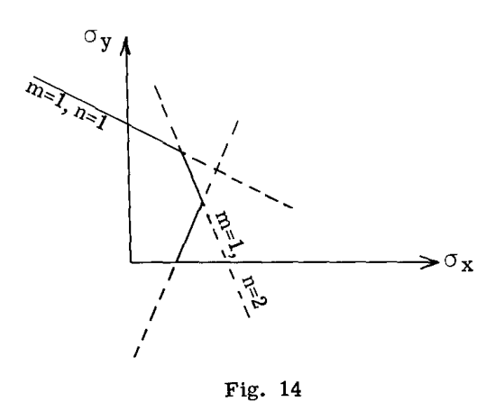

Fig. 14

## A18.19 曲げと圧縮の組合せを受けた単純支持長方形板の座屈

単純支持された長方形板（Fig. 15）を考えてみよう。辺 $x = 0, x = a$ に沿って、次式で与えられる線形分布した端部荷重が存在する：

$$N_x = N_0 \left( 1 - \lambda \frac{y}{b} \right) \quad \text{--- } (39a)$$

# A18.23

これは純粋な曲げと純粋な圧縮の組み合わせである。たわみを再び次の形式でとる：

$$w = \sum_{m=1}^{\infty} \sum_{n=1}^{\infty} C_{mn} \sin \frac{m \pi x}{a} \cdot \sin \frac{n \pi y}{b} \quad \text{--- } (39b)$$

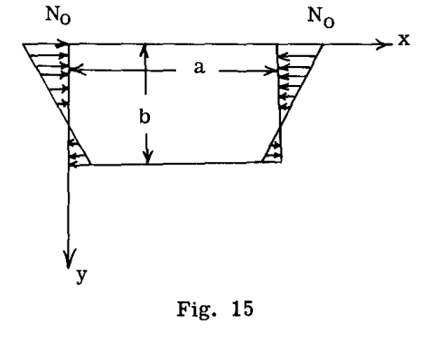

Fig. 15

式 (34) の右辺に代入すると、ひずみエネルギーの変化が求められる：

$$\Delta V_1 = D \frac{a b \pi^4}{8} \sum_{m=1}^{\infty} \sum_{n=1}^{\infty} C_{mn}^2 \left( \frac{m^2}{a^2} + \frac{n^2}{b^2} \right)^2 \quad \text{--- } (39c)$$

一方、仕事の増分は以下の通りである：

$$\begin{aligned}
\Delta W &= \frac{1}{2} \int_0^a \int_0^b N_0 \left( 1 - \lambda \frac{y}{b} \right) \left( \frac{\partial w}{\partial x} \right)^2 dxdy = \\
&\frac{N_0}{4} \left\{ \frac{a b}{2} \sum_{m=1}^{\infty} \sum_{n=1}^{\infty} \frac{m^2 \pi^2}{a^2} C_{mn}^2 - \frac{\lambda a}{b} \sum_{m=1}^{\infty} \frac{m^2 \pi^2}{a^2} \right. \\
&\left. \left[ \frac{b^2}{4} \sum_{n=1}^{\infty} C_{mn}^2 - \frac{8 b^2}{\pi^2} \sum_{n=1}^{\infty} \sum_{i=1}^{\infty} \frac{C_{mn} C_{mi} n i}{(n^2 - i^2)^2} \right] \right\} \quad \text{--- } (39d)
\end{aligned}$$

式 (39c) と (39d) を等しく置き、 $N_0$ について解くと、以下が得られる：

$$(N_0)_{\text{cr}} = \frac{\pi^4 D \sum_{m=1}^{\infty} \sum_{n=1}^{\infty} C_{mn}^2 \left( \frac{m^2}{a^2} + \frac{n^2}{b^2} \right)^2}{\sum_{m=1}^{\infty} \sum_{n=1}^{\infty} \frac{m^2 \pi^2}{a^2} C_{mn}^2 - \frac{\lambda}{2} \sum_{m=1}^{\infty} \frac{m^2 \pi^2}{a^2} \left[ \sum_{n=1}^{\infty} C_{mn}^2 - \frac{32}{\pi^2} \sum_{n=1}^{\infty} \sum_{i=1}^{\infty} \frac{C_{mn} C_{mi} n i}{(n^2 - i^2)^2} \right]} \quad \text{--- } (39e)$$

ここで、 $(N_0)_{\text{cr}}$ が最小になるように係数 $C_{mn}$ を調整する。各係数 $C_{mn}$ に関して式 (39e) の導関数をとり、これらをゼロに等しく置くと、以下が得られる：

$$\begin{aligned}
&D C_{mn} \pi^4 \left( \frac{m^2}{a^2} + \frac{n^2}{b^2} \right)^2 = (N_0)_{\text{cr}} \left\{ C_{mn} \frac{m^2 \pi^2}{a^2} - \frac{\lambda}{2} \frac{m^2 \pi^2}{a^2} \right. \\
&\left. \left[ C_{mn} - \frac{16}{\pi^2} \sum_{i} \frac{C_{mi} n i}{(n^2 - i^2)^2} \right] \right\} \quad \text{--- } (39f)
\end{aligned}$$

$m$ の各値に対して、システム (39f) の解を検討する。 $m = 1$ から始めて、以下のように置く：

$$\sigma_{\text{cr}} = \frac{(N_0)_{\text{cr}}}{h} \quad \text{--- } (39g)$$

(39f) から以下が得られる：

$$\begin{aligned}
&C_{1n} \left[ \left( 1 + n^2 \frac{a^2}{b^2} \right)^2 - \sigma_{\text{cr}} \frac{a^2 h}{\pi^2 D} \left( 1 - \frac{\lambda}{2} \right) \right] - \\
&\beta \lambda \sigma_{\text{cr}} \frac{a^2 h}{\pi^2 D} \sum_i^{\infty} \frac{C_{1i} n i}{(n^2 - j^2)^2} = 0 \quad \text{--- } (39h)
\end{aligned}$$

これらは $a_{11}, a_{12} \dots$ 等に関する同次方程式である。式 (39h) の行列式がゼロであれば、システムは非ゼロの解（板の座屈の可能性を示す）を持つ。この条件から $\sigma_{\text{cr}}$ に対する方程式が得られる。明らかに、システム (39h) は無限個の方程式（ $n = 1, 2, 3 \dots$ ）である。十分な近似は、多数ではあるが有限個の項をとり、有限行列式の解を求めることによって得られる（例えばデジタルコンピュータを使用する）。このようにして、Fig. 12 のような $m = 1$ に対する $\sigma_{\text{cr}}$ 対 $a/b$ の曲線が得られる。 $m = 2, 3 \dots$ 等に対して同様の計算を繰り返すと、2つ、3つ等の半波長に関する同様の曲線が得られる。最小の縦座標を持つ曲線の領域が、Fig. 12 のように安定領域を定義する。

## A18.20 薄板の非弾性座屈

薄板の非弾性座屈の問題は、様々な著者によって広く研究されてきた。このような研究における主な困難は、複雑な応力状態における塑性の応力-ひずみ関係に関するものである。多くの論争のある議論が、理論的な困難を解決することなく文献に現れている。このため、本章では非弾性座屈の理論を展開しない。この主題に関する優れた参考文献のいくつかを以下に挙げる。

C4章では、薄板の非弾性座屈強度の計算に使用する塑性補正係数について説明している。

## A18.21 参考文献

1. Bleich, F: Buckling Strength of Metal Structures. Book by McGraw-Hill.
2. Stowell, E.Z., A Unified Theory of Plastic Buckling of Columns and Plates. NACA Report 898, 1948.
3. Gerard and Becker: Handbook of Structural Stability. NACA T.N. 3781, 1957.
4. Gerard: Introduction to Structural Stability Theory. Book by McGraw-Hill Co., 1962. ```